# RTwitter

In this notebook I want to explore how to pull data using Rtweet.

```r
library(wordcloud)
```

I’m going to look at my favorites, because the limit I can pull is 3,000, and I’ve only favorited around 2,300 tweets. I can then do a little analysis of all of my favorites, and learn a little bit about myself and what I like!

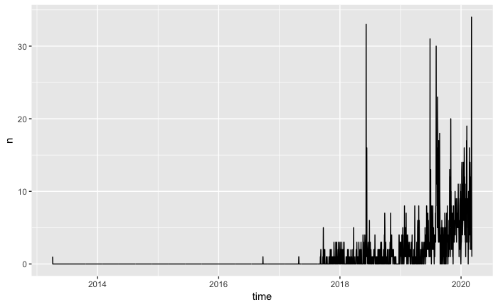

```r
my_faves <- get_favorites('TommyPPickles', n = 3000)
ts_plot(my_faves)
```

I started using twitter in 2017, and you can see thats when all of the favoriting really starts. However, I must have liked a couple of really old tweets from before I was on twitter, because there are a few favorites pre-2017, one is even pre-2014!

Lets see if I can filter the data, or at least the graph, to only show more recent tweets.

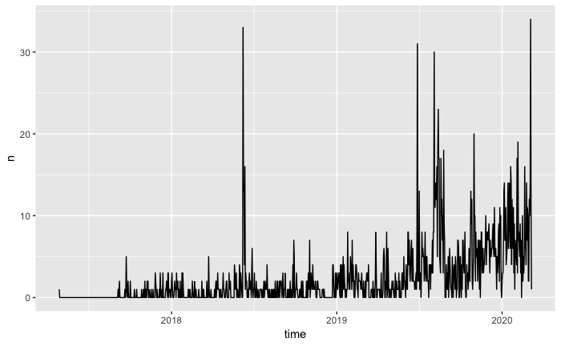

```r
my_faves %>%
  filter(created_at > as.Date('2017-01-01')) %>%
  ts_plot()
```

That certainly makes it easier to see. Lets see what it looks like if I aggregate the data more, like by weeks instead of days (which is the default).

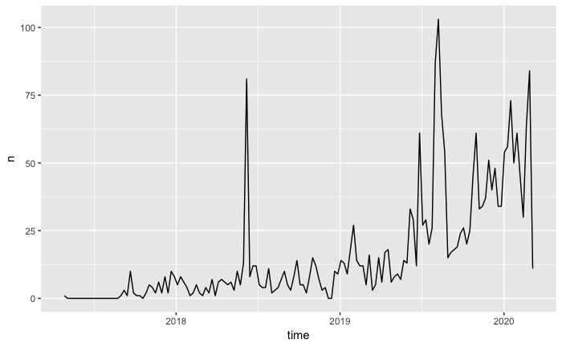

```r
my_faves %>%
  filter(created_at > as.Date('2017-01-01')) %>%
  ts_plot('weeks')
```

That is much smoother!

A couple of observations: the general trend is definitely upwards (I should probably spend less time on twitter), it looks like that trend started shortly before 2019, and there are lots of peaks. Lets look into the peaks!

```r
my_faves %>%
  ts_data('weeks') %>%
  filter(n > 50)
```

| time | n |
| --- | --- |
| 2018-06-07 | 81 |
| 2019-06-27 | 61 |
| 2019-08-01 | 87 |
| 2019-08-08 | 103 |
| 2019-08-15 | 68 |
| 2019-08-22 | 54 |
| 2019-10-31 | 61 |
| 2019-11-28 | 51 |
| 2020-01-02 | 54 |
| 2020-01-09 | 56 |

[output cut: 4 more lines]

The one that really catches my eye is the week of 2018-06-07. Its intriguinging because its one of my top-5 weeks for favoriting tweets, but it comes during a time when I wasn’t really favoriting many tweets. To put it another way, it is likely relatively the most that I’ve favorited if you control for the average number of favorites during recent weeks.

Lets test this by taking an average of the number of favorites in the week before and after, and then subtracting that from the number of favorites.

```r
my_faves %>%
  ts_data('weeks') %>%
  mutate(
    week_prior = lag(n, 1, default = 0),
    week_after = lead(n, 1, default = 0),
    fav_adjustment = (week_prior + week_after) / 2,
    adjusted_favs = n - fav_adjustment
  ) %>%
  top_n(10, adjusted_favs) %>%
  arrange(desc(adjusted_favs))
```

| time | n | week_prior | week_after | fav_adjustment | adjusted_favs |
| --- | --- | --- | --- | --- | --- |
| 2018-06-07 | 81 | 13 | 8 | 10.5 | 70.5 |
| 2020-02-27 | 84 | 64 | 11 | 37.5 | 46.5 |
| 2019-06-27 | 61 | 12 | 27 | 19.5 | 41.5 |
| 2019-08-08 | 103 | 87 | 68 | 77.5 | 25.5 |
| 2019-08-01 | 87 | 26 | 103 | 64.5 | 22.5 |
| 2019-10-31 | 61 | 45 | 33 | 39.0 | 22.0 |
| 2020-01-16 | 73 | 56 | 50 | 53.0 | 20.0 |
| 2020-01-30 | 61 | 50 | 45 | 47.5 | 13.5 |
| 2019-08-22 | 54 | 68 | 15 | 41.5 | 12.5 |
| 2019-11-28 | 51 | 37 | 40 | 38.5 | 12.5 |

To show it, lets make a word cloud of all the tweets that I favorited during the week. It should feature lots of hockey and champion references.

```r
champ_week_faves <- my_faves %>%
  filter(
    created_at < as.Date('2018-06-14') &
      created_at >= as.Date('2018-06-07')
      )
# double-checking the count to make sure its 81
champ_week_faves %>% nrow()
```

```
[1] 81
```

```r
#
champ_week_faves <- champ_week_faves %>%
  select(text) %>%
  unnest_tokens(word, text) %>%
  anti_join(stop_words, by = 'word') %>%
  group_by(word) %>%
  summarize(count = n()) %>%
  filter( # removing https and t.co, as these aren't really relevant
    word != 'https' &
      word != 't.co'
  ) %>%
  arrange(desc(count))
wordcloud2(champ_week_faves)
```

[interactive chart not shown]

Yep, thats definitely when the Caps won the Cup!

Lets do the same analysis for the actual max favorite week, to see what might have been driving all the favorites that week.

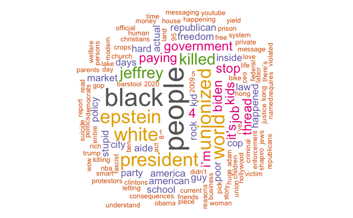

Hmm, this word cloud doesn’t make it clear if there was anything that happened that drove all the tweet favoriting. However, there does seem to be a clear theme: politics. I do heavily use twitter to stay up the date on news, especially as it relates to politics.

I wonder what a word cloud for all my favorites would look like…

[interactive chart not shown]

Wow, I feel seen. I use twitter to follow politics, sports, and data science, and this word cloud does a pretty good job of showing that. You can even get a sense of ranking of those groups; there are many more political references than sports and data science, and I would say there are more sports references than data science.